# GeoNonStat

Sébastien Coube-Sisqueille & Elise Maigné

07/02/2026

# Introduction

The aim of GeoNonStat is to perform Bayesian non-stationary geostatistical modeling.

## Model construction

The model is a hierarchical model with several layers. This section explains what kind of data can be analyzed with the proposed model.

The data is decomposed as
$$y(s) =
x(s)^T\beta + w(s) + \epsilon(s),$$

- $s$ being a spatial coordinate in 2D,
- $y(s)$ being a univariate continuous response variable at the coordinate $s$,
- $x(s)$ being a vector of explanatory variables at the coordinate $s$,
- $\beta$ being a vector of regression coefficient,
- $w(s)$ being an uni-variate spatial effect term at the coordinate $s$ who captures the spatial auto-correlation of the data,
- $\epsilon(s)$ being an uni-variate noise term at the coordinate $s$.

Measurements are done in several coordinates $S = (s_1, \ldots, s_n)$, and having several observations within the same spatial site is possible.

Both $w(s)$ and $\epsilon(s)$ are nonstationary: their behavior may change following the coordinate $s$ and some explanatory variables.

### Regression model for the explanatory variables

It works like an usual linear regression model, in lm() for example. The estimates or confidence intervals may change with respect to an usual linear model due to the spatial effects.

### Nonstationary Gaussian Process model for the spatial effect

#### Tl;dr

- The latent field $w(S)$ has a smoothness parameter that is chosen by the modeler.
- The spatial correlation range and marginal variance are estimated by the model
- The modeler choses if $w(S)$ is (locally) isotropic or anisotropic.
- The modeler also choses if the range of $w(S)$ is allowed to change, in which case $w(S)$ is nonstationary.
- If $w(S)$ is nonstationary:
  - Explanatory variables $x_\theta(s)$ can explain the range, and they must be highly coherent spatially.
  - A latent field $w_\theta(s)$ can capture the spatial coherence of the range, and it must be highly coherent spatially too.

#### Gaussian Process model for $w$

The spatial effect is specified through a *Gaussian Process* who guarantees its spatial coherence.
$$w(S)
\sim \mathcal{N}\left(0,~\sigma^2~M(S, \theta(S),
\nu)\right)$$

While the mean of $w(S)$ is null to avoid identifiability problems with the regression model, its covariance matrix is decomposed into two components:

- $\sigma^2$ is the marginal variance parameter, that is $Var(w(s_1)) = \ldots = Var(w(s_n)) = \sigma^2$.
- $M(S, \theta(S),\nu)$ is the correlation matrix of $w(S)$. It depends on three things:
  - Spatial coordinates $S$. Roughly, the closer $s_i$ and $s_j$ are, the more correlated $w(s_i)$ and $w(s_j)$.
  - Spatial correlation range parameters $\theta(S)$, who control the local correlations structure of $w(S)$. Those parameters are the reason why $w(S)$ is nonstationary (or not).
  - A smoothness parameter $\nu$ who can take value $0.5$ or $1.5$. If $\nu=0.5$, the spatial field will be a bit rougher.

#### Range and smoothness

Imagine $w(S)$ as a landscape of hills. The width of the hills is controlled by the range $\theta$, and their roughness is controlled by the smoothness $\nu$. The smoothness is an important parameter, but it is very difficult to identify with the range, so the smoothness is set by the user to $0.5$ or $1.5$.

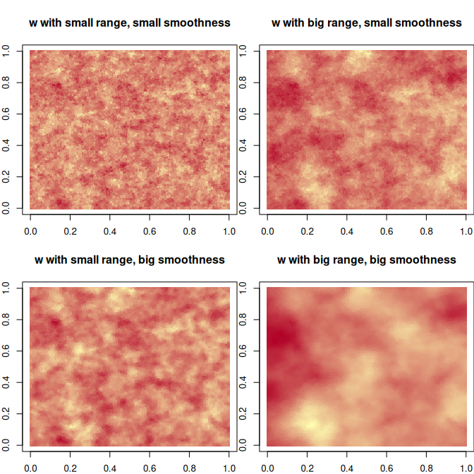

#### Spatial variation of the spatial effect’s range

Now imagine that our landscape behaves differently following the region and/or some explanatory variables. The range parameters of the spatial effect are decomposed as:
$$log(\theta(s)) = x_\theta(s)^T\beta_\theta
+ w_\theta(s)$$

- $s$ being a spatial coordinate in 2D,
- $x_\theta(s)$ being a vector of explanatory variables at the coordinate $s$,
- $\beta_\theta$ being a vector of regression coefficient,
- $w_{\theta}(s)$ being an spatial effect term at the coordinate $s$ who enforces some spatial coherence on $\theta$.

This differs from the decomposition of the data by the fact that there is no noise.

The spatial coherence on $w_\theta$ is enforced by a Gaussian Process, with distribution:
$$w_\theta(S)
\sim \mathcal{N}\left(0,~\sigma^2_\theta~M(S,\theta_\theta,\nu =
1.5)\right)$$

- $\sigma^2_\theta$ is the marginal variance parameter.
- $M(S,\theta_\theta,\nu = 1.5)$ is the correlation matrix of $w(S)$. Now,
  - The range $\theta_\theta$ is constant and chosen by the modeler
  - The smoothness $\nu$ is set to $1.5$.

So one parameter ($\theta_\theta$) is user-chosen, and one ($\sigma_\theta$) is estimated by the model.

For the sake of identifiability, the spatial coherence of $\theta(S)$ must be much higher than the spatial coherence of $w(S)$. There are two practical consequences to that:

- $\theta_\theta$ must be big,
- $X_\theta$ must be really smooth and spatially coherent.

When $X_\theta$ is just an intercept, and $\sigma^2_\theta$ is constrained to $0$, then $\theta(S)$ is constant and the model boils down to a stationary model.

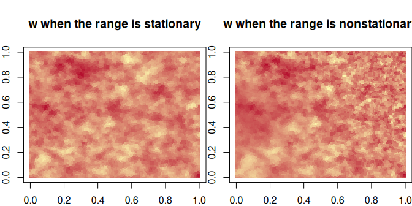

#### Local isotropy or anisotropy of the spatial effect

When the correlation of the spatial effect does not change with spatial orientation, the field is isotropic. If not so, the field is anisotropic. The range parameter of an anisotropic field is an ellipse, which is equivalent to a positive-definite matrix. When the field is isotropic, the ellipse boils down to a circle: the isotropic case is just a particular case of the anisotropic case.

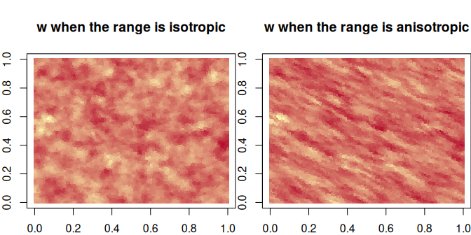

In anisotropic settings, $\theta(s)$ is a positive-definite matrix. The model can be anisotropic and nonstationary, with both the correlation range and direction evolving across space. The previous decomposition, using the logarithm, is replaced by a decomposition who uses the matrix logarithm $mlog(\cdot)$. The matrix logarithm of a positive-definite matrix is a symmetric matrix. The symmetric matrices are modeled using the basis:
$$e_{range} =
\begin{pmatrix} \sqrt 2 & 0 \\ 0 & \sqrt 2 \end{pmatrix},
e_{aniso}^1 = \begin{pmatrix} \sqrt 2 & 0 \\ 0 & -\sqrt 2
\end{pmatrix}, e_{aniso}^2 = \begin{pmatrix} 0 & \sqrt 2 \\ \sqrt 2
& 0 \end{pmatrix}.$$
The choice of the matrix basis used to decompose $mlog(\theta(s))$ is not arbitrary:
$e_{range}$ controls the ellipse size, while the other two components control its shape only. Changing $e_{range}$ will inflate or deflate the ellipses, while changing the two other components will squash the ellipses while leaving their size invariant.

So now, instead of having one component to model, we have three components:

$$\log(\theta(s)) =
\big(x_\theta(s)^T\beta_{range} + w_{range}(s)\big)\, e_{range} +
\big(x_\theta(s)^T\beta_{aniso}^1 + w_{aniso}^1(s)\big)\, e_{aniso}^1 +
\big(x_\theta(s)^T\beta_{aniso}^2 + w_{aniso}^2(s)\big)\,
e_{aniso}^2.$$
There are therefore three times more parameters than in a locally isotropic model.

The spatial coherence on $w_{range}, w_{aniso}^1, w_{aniso}^2$ is enforced by a Gaussian Process, with distribution:
$$w_{range}(S) \sim
\mathcal{N}\left(0,~\sigma_{range}^2~M(S,\theta_\theta,\nu =
1.5)\right); \quad w_{aniso}^1(S), w_{aniso}^2(S) \sim
\mathcal{N}\left(0,~\sigma_{aniso}^2~M(S,\theta_\theta,\nu =
1.5)\right)$$
All three components share the same correlation matrix, but they have different variance parameters depending on their role in the decomposition of the range ellipses. If $\sigma^2_{range}$ is big, then the ellipses will vary in size. $\sigma^2_{aniso}$ is big, then the ellipses will vary in shape and direction. The impact of that on $w$ can be seen in the figure below.

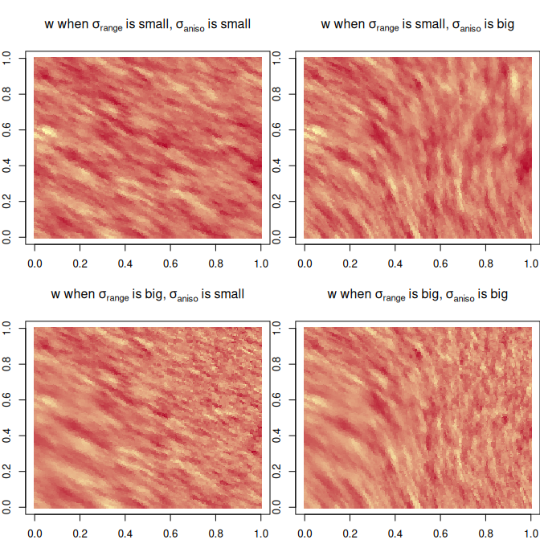

### Nonstationary model for the noise

The variance of the noise $\tau^2(s)$ plays the same role as in a simple linear model, but it may depend on explanatory variables and/or the spatial location. The resulting noise is then heteroskedastic. The decomposition is

$$log(\tau^2(s)) =
x_{\tau^2}(s)^T\beta_{\tau^2} + w_{\tau^2}(s),$$

- $s$ being a spatial coordinate in 2D,
- $x_{\tau^2}(s)$ being a vector of explanatory variables at the coordinate $s$,
- $\beta_{\tau^2}$ being a vector of regression coefficient,
- $w_{\tau^2}(s)$ being an spatial effect term at the coordinate $s$ who enforces some spatial coherence on $\tau^2$.

The spatial coherence on $w_{\tau^2}$ is enforced by a Gaussian Process, with distribution:

$$w_{\tau^2}(S) \sim
\mathcal{N}\left(0,~\sigma^2_{\tau^2}~M(S,\theta_{\tau^2},\nu =
1.5)\right)$$

Contrary to the range, $\tau^2$ does not need to be spatially coherent. Any explanatory variable can go into $x_{\tau^2}(s)$, and the range $\theta_{\tau^2}$ can be small.

### Model architecture

#### Graphical representation

Putting all the elements together, we get the following model architecture.

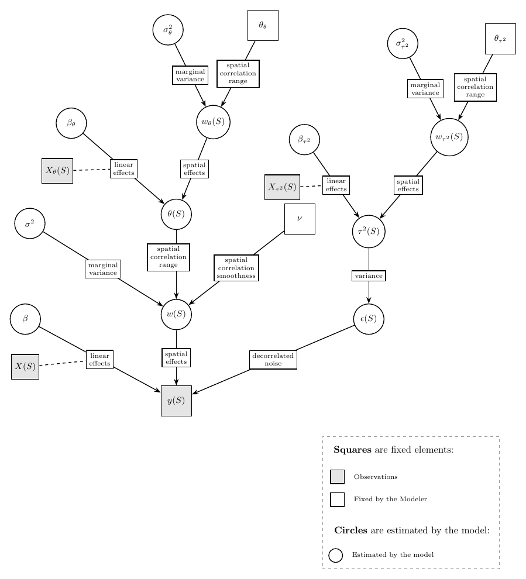

#### Russian doll structure

The Modeler can choose simpler models who are encompassed in the ``full monty’’ model above.

- The Modeler can cancel $w_\theta$ and/or $w_{\tau^2}$.
- The Modeler can provide no variable for $x_\theta$ and/or $x_{\tau^2}$.
- If the Modeler cancels both $w_\theta$ and $x_\theta$, then $w$ is stationary.
- Similarly, if the Modeler cancels both $w_{\tau^2}$ and $x_{\tau^2}$, then $\epsilon$ is stationary.
- An anisotropic model is more general than a locally isotropic model.
- An overspecified model will tend to regress towards a simpler model if presented stationary data. This can be detected if $\sigma_{\tau^2}^2$ and/or $\sigma_{\tau^2^2}$ go to very small values. Also, if an anisotropic model is presented isotropic data, then $\sigma_{amiso^2}$ will go to very small values. Should those situations happen, it is better to restart the model with a simpler formulation.

## Model use

Once the model has run, we can get estimates, and then use those estimates to perform prediction at un-obsered spatial sites. Those estimations and predictions can be used to compare models.

### Estimation

#### Analysis of the response variable $y(S)$

- Fixed effects: estimates and credibility intervals of the regression coefficients $\beta$ are obtained, allowing to interpret the effect of the explanatory variables $x(S)$ on the response variable $y(S)$.
- Spatial effects: estimates and credibility intervals of the spatial effects $w(S)$ are obtained. This allows to understand the spatially coherent patterns in the response $y(S)$, and in particular to construct a map of the spatial effects at the observed sites.
- Denoising: by combining estimates of $\beta$ and $w(S)$, we can obtain $x(S)\beta + w(S)$, which denoises $y(S)$ by removing $\epsilon(s)$

#### Analysis of the noise variance $\tau^2(S)$

- Fixed effects: estimates and credibility intervals of the regression coefficients $\beta_{\tau^2}$ are obtained, allowing to interpret the effect of the explanatory variables $x_{\tau^2}(S)$ on the noise variance.
- Spatial effects: estimates and credibility intervals of the spatial effects $w_{\tau^2}(S)$ are obtained. This allows to understand the spatially coherent patterns in the the noise variance, and in particular to construct a map of the spatial effects at the observed sites.
- Reconstitution of the heteroskedastic noise variance $\tau^2(S)$ at the observed sites using fixed and spatial effects.

#### Analysis of the spatial correlation range $\theta(S)$

- Fixed effects: estimates and credibility intervals of the regression coefficients $\beta_{\theta^2}$ are obtained, allowing to interpret the effect of the explanatory variables $x_{\theta^2}(S)$ on the spatial correlation range.
- Spatial effects: estimates and credibility intervals of the spatial effects $w_\theta(S)$ are obtained. This allows to understand the spatially coherent patterns in the the spatial correlation range, and in particular to construct a map of the spatial effects at the observed sites.
- Reconstitution of the spatial correlation range $\theta^2(S)$ at the observed sites using fixed and spatial effects.

### Prediction

If a new spatial coordinate $s'$ is given, and that the explanatory variables $x(s')$, $x_{\theta}(s')$, and $x_{\tau^2}(s')$ are observed at the new spatial site, the following can be predicted, with a posterior mean and credible intervals.

- Linear effects $x(s')^T\beta$.
- The spatial correlation range parameters $\theta(s')$.
- In turn, the latent field $w(s')$ can be computed.
- Using $x(s')$ and $w(s')$, the denoised interest variable can be computed.
- The variance of the heteroskedastic noise $\tau^2(s')$.
- The interest variable $y(s')$ can then be computed from all the above.